# Презентация по лабораторной работе №2

Дискреционное разграничение прав в Linux. Основные атрибуты

Лушин А.А.

Российский университет дружбы народов, Москва, Россия

Факультет Физико-математических и естественных наук

18 февраля 2005

# Информация

## Докладчик

- Лушин Артём Андреевич
- Бакалавр направления компьютерные и информационные науки
- Кафедра теории вероятности и кибербезопасности
- Российский университет дружбы народов
- Редактор Первого Федерального канала
- lusin5745@gmail.com

# Вводная часть

## Цели и задачи

- Получение практических навыков работы в консоли с атрибутами файлов, закрепление теоретических основ дискреционного разграничения доступа в современных системах с открытым кодом на базе ОС Linux

# Ход работы

## Создание нового пользователя

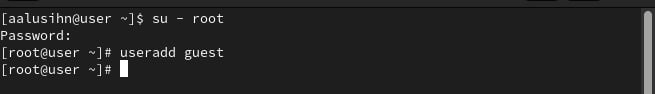

## Проверка прав

С помощью команды “ls -l” мы можем проверить какие права есть у директории или файла. Всего есть 3 категории прав: для владельца файла (U) , для владельца группы (g) и все остальные (o). Так же в каждая из категорий есть 3 права: r - read, w - write, x = exec

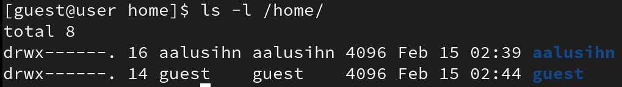

## Работа с правами

С помощью команды chmod мы можем забрать или дать права у определённого файла или директории. То есть если я пропишу 000, то у файла заберутся вообще все права. Если же я пропишу 700, то директория получит всевозможные права.

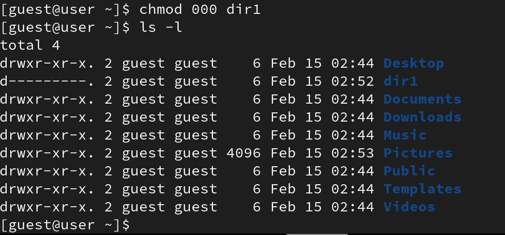

## Таблица 1

По ходу лабораторной работы я составил таблицу,где представлены 64 возможных выдачи прав. Начиная с прав 000 для директории и 000 для файла, заканчивая правами 700 для директории и 700 для файла. В таблице прописана возможность работы с файлом или директорией и что можно делать при определённых правах, а что нельзя.

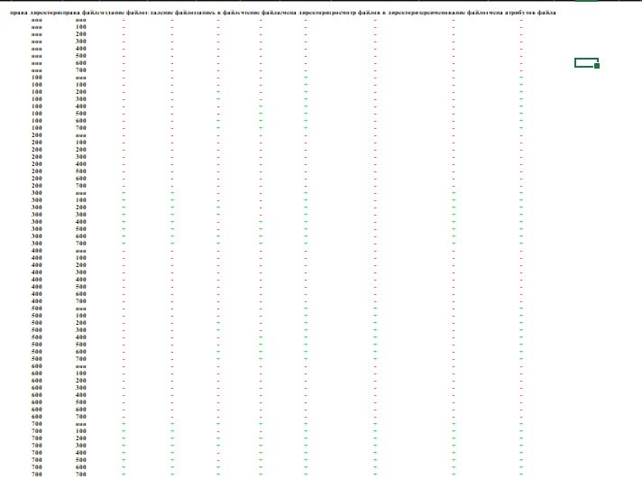

## Таблица 2

Так же мы выполнили вторую таблицу, но она зависит от первой. Мы вписали необходимые права для каждого действия. То есть, если мы хотим создать файл в директории, то необходимы права 300 на директорию и 000 на файл.

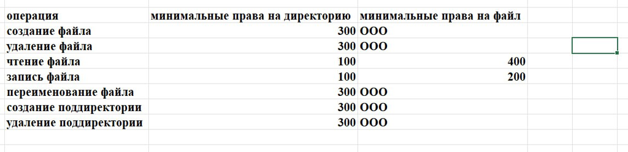

# Результаты

## Вывод

Я получил практические навыки работы в консоли с атрибутами файлов. Так же закрепил теоретическую основу дискреционного разграничения доступа в современных системах с открытым кодом на базе ОС Linux